# Methodology

Tyler Peckenpaugh

5/19/2019

# Introduction

Before the details of the current research can be outlined, it's first necessary to explain some of the terms and mechanisms involved. Most critically, it's necessary to be clear on what a garden path is, and what causes the phenomena.

## What is a garden path?

The occurrence of garden-path (GP) effects are generally attributed to a clash between structure-first parsing strategies, e.g. @Frazier1979-pb’s *Minimal Attachment*, and the actual intended structure of the sentence in question.

```
Attach incoming material into the phrase-marker being constructed using the fewest nodes consistent with the well-formedness rules of the language under analysis [@Frazier1979-pb]
```

If we assume that the parser builds structure by following these types of constraints or rules in a programmatic way, without concern for meaning, it's easy to see how one might end up with a parse that denotes an implausible situation, or even an ungrammatical sentence. An example is the commonly studied garden path sentence, “The horse raced past the barn fell,” [@bever1970]. Here, the initial parse incorrectly assumes that the matrix subject is the unmodified NP the horse, per *Minimal Attachment*, and takes the matrix verb to be raced, as in the sentence, “The horse raced past the finish line.”

1. The horse raced past the barn fell [@bever1970]
   1. [<sub>S</sub> [<sub>NP</sub> The horse] [<sub>VP</sub> raced past the barn]] ??? [<sub>VP</sub> fell]
   2. [<sub>S</sub> [<sub>NP</sub> The horse raced past the barn] [<sub>VP</sub> fell]]

The attempted parse represented in structure (1) crashes, as it isn“t possible to incorporate the final word fell in a grammatical way. In order to obtain the grammatical parse, (1 b) where the matrix subject is the horse raced past the barn, almost the entire structure of (1 a) must be discarded. The subject is not the horse, and the main verb is not raced. Rather, the subject is a noun phrase (NP) containing a reduced relative clause raced past the barn. Only after remediation can fell be properly incorporated as the matrix verb. This finally results in a grammatical sentence, with a structure comparable to,”The horse (that was) raced past the barn was hungry." Garden-path effects can result any time the assumptions made by the parser clash with the actual structure of a sentence.

## PP-attachment garden paths

The type of garden-path sentence that this study is concerned with centers around the temporarily ambiguous attachment sites for a prepositional phrase (PP). Consider:

2. He had planned to cram the paperwork [<sub>PP1</sub> in the drawer] [<sub>PP2</sub> into his briefcase].
3. He had planned to cram the paperwork [<sub>PP1</sub> in the drawer] [<sub>PP2</sub> of his filing cabinet].

The other sentence, (3), should not represent any difficulty. The ambiguity is resolved such that PP1 can, and in fact must, attach high, since the subsequent PP of her filing cabinet (PP2) cannot plausibly attach as a sentential modifier, nor a verbal argument or modifier, and the sentence is incomplete without a destination of the cram action. By examining these sentences, the study proposed aims to expand understanding of human sentence processing in general, and specifically the relationship between syntactic structure and prosodic structure. Further, this will explore any contrast there might be in the impact of declarative and interrogative contexts on parsing, which has been under studied.

## An observation

These attachment ambiguities which are difficult to parse in the declarative, appear to be less difficult to parse when presented in yes-no interrogative context. Consider again the somewhat difficult to process sentence in (2), repeated below as (4) for convenience.

4. He had planned to cram the paperwork [<sub>PP1</sub> in the drawer] [<sub>PP2</sub> into his briefcase].

According to the intuition of many native speakers of American English, the difficulty of (4) is at least somewhat lessened in (5):

5. Had he planned to cram the paperwork [<sub>PP1</sub> in the drawer] [<sub>PP2</sub> into his briefcase]?

That is, while both sentences contain a temporary ambiguity for the attachment of PPs occurring in string-linear sequence at the end of an utterance, it is more likely in (5) that a listener or reader will come away with a plausible interpretation. This study explores the factors involved in why that is, and seeks to uncover a behavioral correlate of this intuition. If the existence and mechanics of this effect can be pinned down, it will lend insight into what information the parser has access to when making decisions, or when repairing broken parses. This initial observation reveals a robust program of research with many interwoven questions.

One of the many questions is: can speaker behavior be shown to reflect the intuition? To say it another way, is there some behavior that is correlated with the reduction in difficulty of parsing PP-attachment garden paths that can be measured? Peckenpaugh (2016) represents one attempt to find such a correlate, and this paper continues that search.

One might also ask what property or properties of polar questions might lead to an easier parsing of garden paths, or at least to the perception that they are easier to parse as polar questions than as declaratives. Because there are minimal differences between the polar question and declarative version of a given sentence, it is fairly easy to assume that the cause lies in one of two domains: the prosodic changes triggered by the use of question intonation, or the pragmatic and semantic properties that are not shared across the versions.

An obvious reflex of the former possibility is another question: how are the various versions of these sentences actually pronounced? This question is deceptively difficult to answer; the reported study seeks to answer it, but while the recordings collected provide some insight, more work is likely needed to satisfactorily provide an answer.

Likewise, the latter possibility leads one to wonder: what are the semantic and pragmatic differences between a polar question and its declarative counterpart? This question can be approach in a more theoretical way, and has been to some degree in the literature. That said, it remains to be determined how those properties could lead to an easier parsing process, and whether or not a satisfactory explanation for the intuition at large can be pulled from these differences.

# Background

This section goes over evidence supporting the claim that prosody can impact parsing decisions, even in silent reading.

## Can prosody affect parsing?

A number of studies have shown that in listening to speech, prosodic cues appear to help reduce the frequency with which incorrect parsing (i.e. a garden path) occurs. For example, @Kjelgaard1999-xd conducted a study using digital manipulation of recorded speech to create three versions of sentences containing a garden path temporary ambiguity (discussed above). They recorded speakers saying sentences with natural prosody, such as the following pair:

6. [When Roger leaves] the house is dark. (Early closure)
7. [When Roger leaves the house] it's dark. (Late closure)

They then cross-spliced these together to make several versions. One version had prosodic cues which cooperated with the intended reading of the sentence; another attempted to have “neutral” prosody; and the third used intentionally misleading prosody. The initial fragment of each was then presented to participants (the portion from the beginning of the sentence to the word house in (6 - 7) and they were asked to agree or disagree with whether a visually presented word, either *is* or *it's* was likely to be the next word in the sentence. Participants gave more accurate and speedier judgements when the prosodic cues lined up with the correct parsing. The results of this study, as well as a growing body of literature, suggest that that prosodic information can (or perhaps must) be used by the parser in making processing decisions.

## Prosody in silent reading

The experiment presented in this paper is conducted using silent reading, and it is perhaps less intuitive to assume that prosody might play a role in the processing of silent reading compared to the processing of spoken utterances. Nonetheless, there is some evidence to support such an effect; as such, a positive result here is not a reason to dismiss the prosodic explanation for the effect, although it also can't support that explanation over others. Consider @Fodor2002-io analysis of relative clause attachment preference. This concerns sentences such as (8):

8. Someone shot the servant<sub>N1</sub> of the actress<sub>N2</sub> [<sub>RC</sub> who was on the balcony].

```
Align($\alpha$Cat, E; $\beta$Cat, E)

  a. Align (GCat, E; PCat, E)
  b. Align (PCat, E; GCat, E)
  c. Align (PCat, E; PCat, E)

*GCat ranges over morphological and syntactic categories; PCat ranges over prosodic categories; E = Right or Left [@Selkirk1986-hc, p. 6]*
```

@Truckenbrodt1999-vd provides a prose-based formalization of the same idea. He describes what I will call *Align<sub>R</sub>* which can be easily generalized to described what I will call *Align<sub>L</sub>*, the same constraint except that it calls for aligning phrases at their left edges rather than their right edges.

9. **Align-XP/R**  
   For each XP there is a PP such that the right edge of the XP coincides with the right edge of the PP, where XP is a maximal projection and PP is a Phonological Phrase. This constraint represents the end based mapping assumption for Major Phonological Phrases in English, whose right end is supposed to align with the right end of Maximal Projections [@Truckenbrodt1999-vd, p. 223].

Essentially, Selkirk argues that relative ranking of alignment constraints for the left edge of phrases (*Align<sub>L</sub>*) with those for the right edge of phrases (*Align<sub>R</sub>*) can impact the distribution of prosodic breaks. These alignment constraints dictate that the edges of prosodic units (and thus the location of prosodic breaks) should align with the edges of syntactic constituents. Because the prosodic break that encourages high attachment is one which aligns with the left edge of the RC, postulating that *Align<sub>L</sub>* is ranked above *Align<sub>R</sub>* in languages like French that prefer high attachment can account for that preference (remember that a prosodic break in that place has been shown to encourage a high attachment interpretation). In languages where low attachment is preferred, we can assume that *Align<sub>R</sub>* is ranked higher, and thus a prosodic break is more likely to occur after the RC than before.

The same sort of argument can explain the difference in tendency between long and short RCs. Consider Selkirk's [-@selkirk2011-hp] *BinMin* defined below.

10. **BinMin($\phi$)**  
    A $\phi$ (phonological phrase) must consist of at least two $\omega$ (phonological words).

If we assume, in Optimality Theoretic (Prince & Smolensky, 1993) terms, that a constraint like *BinMin* is ranked above *Align<sub>L</sub>*, then it seems quite reasonable to assume that a prosodic break before a short RC (which would encourage high attachment) is much less likely than before a long RC. That is, when the RC is short, its left edge is prevented from aligning with the beginning of a prosodic phrase (it violates *Align<sub>L</sub>*) by the higher ranked BinMin. Longer RCs can have their left edge align with the start of a prosodic phrase, and thus can have the high-attachment encouraging prosodic break.

This analysis, of course, assumes the presence of prosodic cues, which are only overtly present in spoken utterances (punctuation aside). Given the elegance and explanatory power of this analysis, it seems reasonable to at least consider the further assumption necessary for it to also explain the phenomenon as it occurs in silent reading; which is that readers project prosodic structure over sentences even when they are read silently.

## Prosody of questions vs. declaratives

In pursuing the possibility that it is the intonation and prosody of polar interrogatives which creates the intuitive contrast that this study investigates, we must consider what question intonation actually sounds like. It is generally agreed that in American English, the intonation of a polar (yes/no) question has the property of a final rise. Indeed, this has been confirmed in corpus studies such as @Hedberg2017-er who found that 79.8% of the 410 American English yes/no questions in their study (ten-minute phone conversations from the CallHome Corpus of American English and the Fisher English Corpus) had a “low-rise nuclear contour” (L*H-H%, L*H-↑H%, or L*L-H%)[^1]. To briefly explain their ToBI notation, a tone T is either L for low or H for high; T* is anchored to the stressed syllable, and T- and T% are boundary tones (intermediate phrase boundary and intonational phrase boundary respectively). See, e.g., *Guidleines for ToBI labeling* [@Beckman1997-eu] for a more thorough explanation of ToBI. An additional 10.7% of the @Hedberg2017-er data had a “high-rise nuclear contour” (the authors categorizes the following tunes as “high-rise nuclear contours:” H*H-H%, or !H*L-L%). That leaves only 9.5% spread across the other 5 categories (High-fall, Rise-fall, Low-fall, Fall-rise, and Level). Only 5.6% of the data showed a falling contour. According to the authors' analyses, these contours occur on the final main stress of a sentence and thereafter. In the case of the types of sentences examined in the current study,that would result in a rising contour on the head noun of the final PP.

11. Did Jed cram the newspapers under the sofa in the [<sub>L*H-H%</sub> guestroom].

The need to prepare for that rising tone might make a prosodic break before the PP more likely, and thus ease reanalysis or even encourage a different prosodic chunking which might encourage high attachment.

A brief informal survey found that most speakers maintain low tones on prior stresses, although some had a H tone on the subject noun. It also varied between speakers and between sentences as to whether there is a prosodic boundary (marked by a low tone and/or pause) immediately before the rise (after PP1) or not.

## Syntactic structure of PP-attachment ambiguities

12. Jed crammed the newspapers under the sofa in the trashcan.
1. # … [<sub>VP</sub> crammed [<sub>NP</sub> the newspapers] [<sub>PP1</sub> under [<sub>NP</sub> the sofa [<sub>PP2</sub> in the trashcan]]]
2. … [<sub>VP</sub> crammed [<sub>NP</sub> the newspapers [<sub>PP1</sub> under [<sub>NP</sub> the sofa ]] [<sub>PP2</sub> in the trashcan]]

In the case of this sort of garden path, *Minimal Attachment*, or some variation thereof, results in a structure where the first PP attaches to the verb phrase (VP) as an argument, i.e. [<sub>VP</sub> V NP PP1], which leaves nowhere for the second PP to attach but as a modifier of the noun phrase (NP) inside PP1 (##[<sub>PP1</sub> on [<sub>NP</sub> the swing [<sub>PP2</sub> in his stroller]]]). This initial parse (12~ ~a) is pragmatically implausible, as one does not generally find swings inside strollers. Reanalysis is required to bring about the correct parse (12~ ~b), where PP1 attaches as an NP modifier of the direct object [<sub>VP</sub> V [<sub>NP</sub> N PP1] …] which allows PP2 to attach as a VP argument, i.e. it is the cranky little boy on the swing who is being placed in the stroller.

Note that *Minimal Attachment* as defined by Frazier (1979) is somewhat at odds with modern syntactic theory (cf. Chomsky 1995, p. 62). As originally postulated, it relies on a verb with multiple internal arguments incorporating each of those arguments as a sister (i.e. a ternary branching structure: [VP V NP PP]). With more modern theories where binary branching is obligatory, it becomes less clear that the VP attachment site for PP1 actually creates fewer nodes than the lower NP attachment site. Nonetheless, the preference for VP attachment in these kinds of sentences is there, be it due to *Minimal Attachment*, a preference for arguments over non-arguments, or whatever else: see evidence from e.g. Rayner et al. (1983) and Clifton et al. (1991). I assume, following Frazier (1998) that it can be adequately described by reformulating *Minimal Attachment* to include a preference for argument relations over non-argument ones, or else through careful consideration of the syntactic structures involved and reformulation of *Minimal Attachment*. The precise definition of this parsing strategy is not a concern of this paper, but it is assumed to be at play.

## Predictions for the current study

This study is concerned with a number of issues. First: is attachment in any way encoded in the speech signal? I hypothesize, following e.g. Schafer et al. (2000), that we can use prosody to diagnose attachment site. Assume the following basic configuration:

13. SUBJ V OBJ PP1 PP2

I suggest that high attachment of PP2 will be marked by a prosodic boundary between PP1 and PP2 (for discussion of what constitutes a prosodic boundary, see Streeter, 1978 and Salverda et al., 2003). Low attachment of PP2, on the other hand, will lack any substantial boundary marking.

14. *Hypothesis 1* High attachment of PP2 is prosodically marked by a boundary tone between PP1 and and PP2.

The second issue: what factors impact immediate on-line parsing, and what factors only affect later, post-parse considerations? To address this, the study will employ the double reading paradigm of Fodor et al. (2018) (more on double reading in the methods section). For example, if first-pass parsing ignores semantic information, then implausible parses should be more frequent in cold readings (i.e. without preview) of a garden-path sentence than in a second reading of the same sentence.

15. *Hypothesis 2* A cold reading (no preview) of a GP sentence will exhibit less natural prosody (more hesitation at and after the disambiguating region) than: A cold reading of a non-GP sentence. A previewed reading of a GP sentence.

*Hypothesis 2* and *3* together make a third prediction: readers should struggle more on the cold reading of a GP sentence to obtain a plausible structure, and thus the appropriate prosody, than on a previewed reading.

16. *Hypothesis 3* A cold reading of a garden-path sentence will more often be produced with prosodic structure that represents an implausible or ungrammatical parse of the string (low attachment of PP2), whereas a previewed reading sentence will more often be pronounced with the prosodic structure that represents the intended parse (high attachment of PP2).

Note that hypothesis 3 can’t be applied in cases where the reader fails to successfully and fluently produce the sentence (which may sometimes happen, due to the GP effect). Finally, I investigate an intuition originally discovered by Janet Dean Fodor and Dianne Bradley: that these GP sentences are not as difficult to parse when encountered in interrogative, as opposed to declarative, context.

17. *Hypothesis 4* A cold reading (no preview) of a declarative GP sentence will exhibit less natural prosody (more hesitation at and after the disambiguating region) and be more likely to be produced with prosodic structure that represents an implausible or ungrammatical parse of the string than a cold reading of an interrogative GP sentence.

# Methodology

This section outlines the methodology employed for the reported study. The methodology outlined is referred to as the *Double Reading Procedure* and was first implemented by @fodor2019center. Participants are asked to read sentences twice, once without any previewed (cold reading or reading-1), and then again after unlimited preview (previewed reading or reading-2).

## Participants recruitment

The participants in this study were all undergraduate students at Queens College, CUNY, enrolled in Psychology 101. These students were required by the university to participant in studies for course credit. Self reported age ranged from 18 to 25 years. Participants were recruited using the Queens College Sona system, which is software designed for univeristy participant pools. Students saw the blurb in (18) and were able to schedule their own appointment time within the hours offered (Monday - Thursday, 10am to 4pm).

18. **Recruitment**  
    You will be asked about your reading habits and then asked to read complex sentences out loud while being audio recorded. Recordings of your voice will be analyzed, but will be kept strictly confidential. The process will take no more than 1 hour. Note that the study takes place in Queens Hall, which is about half a mile from the main Queens campus. See directions on the QC website, URL below, for how to get here. The room is 335D, on the third floor. Entrance to the building is in the back.

All participants were self identified native and primary speakers of American English. One participant was disqualified post-hoc, although still paid for time spent, after producing a Carribean English pronucnciation pattern. One other participant was excluded post-hoc due to an extremely disfluent reading cadence.

## Equipment and software

The experiemnt was presented on a laptop running Windows 10 with stickers on the keyboard labeling relevant keys. The left shift key was labeled *START*, right shift was labeled *NEXT*, and the touchpad was labeled *DONE*.

The presentation of items and instruction[^2] was done using the Open Sesame software [@os2012] which provides both a graphical user interface, scripting language, and interpretation of Python code, for precise control of experimental presentation.

Recording was done using a Blue Yeti USB microphone position near the participant’s left hand and angled to point at the space in front of the participant’s mouth. The angle was adjusted for each participant’s height. It recording 44.1kHz single-channel audio. Each recording was saved to the laptop’s hard drive and also immediately uploaded to a Microsoft OneDrive account provided to the author by the Graduate Center, CUNY. No personally identifying information other than the quality of the participants’ voices was embedded in the recordings. Only a handwritten ledger tied participants to the identifier used in the filename of the recordings.

## Procedure

Participants sat at a computer and used keyboard button presses to navigate the experimental presentation. They recieved thorough instructions and completed three practice items, the consulted with the experimenter, before beginning the main portion of the study. The study also contained 4 pseudo-practice items that were not included in any analyses, in order to allow some time for the participant to settle into the procedure before any results were recorded.

Each experimental item was preceeded by a screen showing a line of ten Xs with its left edge aligned with the left edge of the to-be-revealed sentence. This was intended to fix the participant’s attention on the start of the sentence, and hopefully avoid unintended lookahead. This screen remained visible indefintely, until the participant pressed *START*.

Immediately after *START* was pressed, recording of the first reading began and the sentence appeared on the screen on a blue background. The recording continued and the screened remained visible until the participant pressed *NEXT*.After pressing *NEXT*, a screen appeared with instructions telling the participant that they were between readings, and needed to press *START* to reveal the sentence again and prepare for their second reading. Immediately after *START* was pressed, the first recording ended and the second recording began, and the sentence reappeared, this time on a green background.

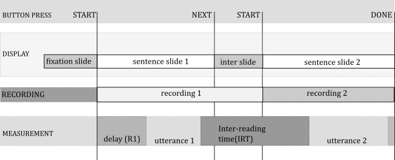

Procedure diagram

The shifting of required key presses and the changing background color were intended to aid the participant in remember where they were in the process, and to prevent accidental double-presses of any given button from having unintended side effects. It took some time for the participants to adapt to the somewhat complicated procedure, but most seem to have gotten the hang of it before the first real item was presented.

### Instructions to participants {##inst}

Participants were given a verbal overview of the experimental procedure and then asked to read a one page printout of the procedure before signing a consent form. After signing a consent form, participants sat at the computer and were once again walked through instructions before the first practice item was presented.

## Materials

A number of considerations went into creating the materials for this study. The experimental stimuli are based on earlier pilot study exploring this same phenomenon [@qp2], but with several issues with that study’s experimental items corrected.

One of these issues was that the verbs did not all strongly subcategorize for a PP-argument. This could affect the strength of the garden path effect, since the strength of that subcategorization might impact the amount of sway that the parsing strategy of *Minimal Attachment* or *Argument Preference* has on the parse. Theoretically, verbs with stronger subcategorization for a PP-argument would result in a stronger garden path effect, or more difficulty in understanding the sentence.

Another issue had to do with the level of detail present in the sentences, especially when they were presented as yes/no-questions. When it’s clear that the speaker already knows so much about the situation, it becomes difficult to imagine a pragmatically plausible context where the question would be asked. Such sentences might be described as “prosecutorial[^3].”

There was also an issue of whether the temporary ambiguity in some of the non-garden path items was ever fully disambiguated. This section will go over considerations taken in order to adjust the stimuli from the earlier study into more systematic and consistent format. The construction of these items is discussed in detail in the rest of this section.

### Main verbs in experimental items

An earlier pilot study exploring this same phenomenon (Peckenpaugh, 2016) had several issues with its materials. One of these issues was that the verbs did not all strongly subcategorize for a PP-argument. This could affect the strength of the garden path effect, since the strength of that subcategorization might impact the amount of sway that the parsing strategy of Minimal Attachment or Argument Preference has on the parse. Theoretically, verbs with stronger subcategorization for a PP-argument would result in a strong garden path effect.

19. Weak PP-argument subcategorization (*hide*)
1. The gangsters had hidden the shotguns in a U-Haul truck in an old outhouse.
2. The gangsters had hidden the shotguns.
20. Strong PP-argument subctategorization (*cram*)
1. Justin had crammed the old newspapers under the couch in a small wastebasket.
2. * Justin had crammed the old newspapers.

The examples in (19) and (20) point out that while you really must cram something somewhere, you don’t necessarily need to say where you hide something. That is, the verb *hide* seen in (19) does not strongly subcategorize for a locative argument (hence the acceptability of (19b)), while cram (20) does, rendering (20b) unacceptable. Because of the asymmetry in subcategorization strength, sentences like (19) might not trigger as strong a garden-path effect, because the parser might assume that no PP-argument is forthcoming, while for (20) the parser will jump at the opportunity to parse a PP as an argument. In designing the items for this study, only verbs with strong PP-argument subcategorization will be used. The four verbs selected were: *cram*, *put*, *stick* and *set*.

### Complex tense

To minimize the morphology present on the PP-argument-selecting main verb (e.g. *cram*), each sentence contained a past-tense auxiliary verb and past participle verb before the infinitive version of the main verb. The use of an auxiliary makes the words present in the declarative exactly the same as in the interrogative by eliminating the need for “do-support” and adjusted morphology on the main verb (i.e. rather than “He crammed …” vs. “Did he cram …?” we have “He had crammed …” vs. “Had he crammed …?”). The auxiliary is always *had* and the past participle is always one of the following four: *decided*, *intended*, *wanted*, and *planned*. The presence of these preface verbs also help to aleviate the oddity of the yes/no questions, because it is understandable to question someone’s intentions, even when a large amount of detail is already known; whereas, questioning the details themselves when they are already known leads to the “prosecutorial” issue mentioned earlier.

21. Had he planned to set the appetizers on the platter from his cousin?
22. Had he set the appetizers on the platter from his cousin?

It seems less odd to wonder whether *he had planned* to do something, as in (21) when we know so many details, rather than to wonder if he did as in (22). The preface verb also seems to attract the focus of the yes/no question, providing a somewhat controlled environment for what can be difficult to ascertain: in (22) the focus could be on any number of elements, with no easily assumed default. The default focus in (21) seems to me to be on *planned*.

### Prepositions and disambiguation

Every version of each experimental item should be fully disambiguated by the preposition heading the final PP. When PP2 attaches low, a preposition that is not compatable with being the resultative/locative argument of the verb but can be a modifier of the noun of the preceeding PP is used: *from* or *of*. When the final PP attaches high, a preposition that is not compatable with being a modifier of the noun in the preceeding PP but can be the resultative/locative argument of the verb is used: *into* or *onto*.

23. Had he planned to set the appetizers on [<sub>NP</sub> the platter [<sub>PP2</sub> *from* his cousin]]?
24. Had he planned to set the appetizers on [<sub>NP</sub> the platter] [<sub>PP2</sub> *onto* the buffet]?

This clear disambiguation should prevent any lingering processing issues due to ambiguity in the non-garden path versions of the sentences.

### Length

Length was tightly controlled across items. For experimental items, all sentences were between 66 and 75 characters long, and between 13 and 15 words long. The length never varied across the ±Q condition. Across the ±GP condition there was a maximum length difference of one character. Two items varied in word length across ± by one word. For all length variations (word and character), an equal number were longer in the +GP condition as in the -GP condition. They ranged from 18 to 22 syllables.

Control over filler length was slightly less stringent. They ranged from 63 to 79 characters and 12 to 14 words.

## Experimental groups and order of items

No participant saw more than one version of each sentence, and each participant saw one version of every sentence. Each participant saw the same number of each type of sentence: 4 garden path declaratives, 4 garden path interrogatives, 4 non-garden path declaratives and 4 non-garden path interrogatives. The experimental item were presented in pseudo-random order, interspersed with 1 to 3 fillers and with two experimental items never occuring in the same version twice in a row (e.g. after declarative garden path, the next experimental item was never also a declarative garden path).

The four versions of the experimental sentences resulted in four groups. A split-half ordering (where the first 24 of the items presented to one group was the second 24 presented to the other) resulted in 2 versions for each group, and so there were 8 groups in total.

## Inter-reading time (IRT) measurement

Subjects were asked to read each sentence twice, once with no preview at all (reading 1, a cold reading), and then again after unlimited preview (reading 2, a previewed reading). Inter-reading time (IRT) is a measure of the amount of time between when a subject stops speaking after a cold reading and when they begin speaking for a previewed reading.

IRT was measured using a Python script and Google’s WebRTC Voice Activity Detection (VAD) over 44.1kHz WAV files downsampled to 8kHz via SOX[^4]. This VAD system uses Gaussian Mixture Models to make probabilistic decisions on whether a given audio frame is speech or noise (see [@gmm1] for a complete explanation). Google’s implementation takes one paramater, which they call aggressiveness: a 4-tier setting for the level of confidence necessary to call a gvien frame speech. I call this “rejection rate”, where a higher rejection rate means that the model requires a high level of confidence before assuming a frame is speech, i.e. it is more likely to label something noise than speech. The implementation codes this setting as 0-3, where 0 is the most lenient (most likely to label a frame as speech) and 3 is the most stringent (most likely to label a frame as noise).

The recordngs vary in the volume of the speaker’s voice and the amount of background noise present. An algorothm was constructed to allow for the most stringent measurement of the least modified data that gave plausible measurements. Specifically, each file was measured using the highest possible rejection rate for the VAD algorithm and no modification of the file. If the timings detected were not plausible, the timings were re-measured with the same rejection rate, but after the recording had undergone a 200Hz high-pass filter[^5] (HPF). If that still failed, a 400Hz HPF was used. After a further failure, the rejection rate for the VAD was lowered, and the whole thing was tried again (0, 200Hz, 400Hz); and that process was itself repeated until the lowest possible rejection rate was tried of the four possible settings.

A plausible set of measurements had to meet the following criteria:

*Utterance length:* An utterance length between 2s and 10s, where utterance timing is the longest contiguous span in the recording that VAD reports as phonation, with breaks in phonation of less than 1s not breaking contiguity. @goldman1961-pa found that a large majority (82.5 to 87%) of pauses in fluent speech are less than 1s. Stimuli range from 18-22 syllables in length. If we assume a speeach rate of 3 to 7 syllables per second [@jacewicz2010-sr] we would expect utterances between 2.5s and 7.3s. Conservative thresholds higher and lower than the expected were used, especially on the higher end to allow for any processing or fluency.

*Minimum leading silence:* A leading silence (“delay”) of more than 120ms. Even a very fast human reaction time should not permit a delay shorter than 120ms.

*Maximum edge silence:* A maximum trailing and leading silence length of less than 95% of the file’s length was also used, in order to filter out recordings that do not represent a valid trial. Very long delays less than this very conservative threshold are dealt with in the data clean up rather than via phonation detection.

## Prosodic judgements

She was asked to report on whether or not she heard a prosodic boundary directly after the region labeled **V**, directly after the region labeled **OBJ**, and directly after the region labeled **PP1**. The following definition of prosodic break was provided:

> Please work with the assumption that “prosodic boundary” in what follows is any subset of the following features, clustered in such a way as to trigger your intuition that a new prosodic element (of any size) is beginning: pitch change, volume change, segmental lengthening, or pause.

The judgements requested also included whether or not the speaker struggled, where that struggle began, whether or not the speaker used question intonation, and which break(s) were stronger or more prominent than which other break(s).

Detailed instructions on the order in which items should be listened to, both within speaker and across speakers, were also provided. The result was that she never listened to both readings of a sentence in sequence; she never listened to two reading 1 versions of different sentences in sequence; and she never listened to the sentences in the same order for a given participant as she did for the previous one.

# Results

This section reports various analyses of the recordings obtained. The analyses include the effect of sentence type (declarative vs. interrogative, garden path vs. non-garden path) on the location of prosodic breaks, as well as “study” or inter-reading time (IRT). In order to evaluate the extent to which participants followed the instruction to read immediately for reading 1 and then study the sentence for reading 2, the amount of time that a sentence is displayed before a participant begins to read it (delay) is also discussed and compared across reading 1 vs. reading 2.

## Participants in the reported analyses

There is a total of 32 participants included, 48 total items, 16 of which are experimental items, with each item read twice by each participant. The 32 filler items are not included in analyses except where specified. The same recordings are used for all analyses.

No. of participants per version-order combination

|  | Order Order 1 | Order Order 2 | Sum |
| --- | --- | --- | --- |
| Version 1 | 5 | 4 | 9 |
| Version 2 | 4 | 4 | 8 |
| Version 3 | 4 | 4 | 8 |
| Version 4 | 2 | 5 | 7 |
| Sum | 15 | 17 | 32 |

Some items are missing due to technical issues during data collection. Other data were excluded due to factors explained later. Ultimately, 978 recordings are analyzed (489 pairs).

## Prosody

This subsection presents the results of the independent rater’s judgements regarding prosodic boundaries. Data are excluded if either recording from a pair of recordings (reading 1 or reading 2) is missing (there were 9 incomplete pairs excluded) because without the other member, it is difficult to determine the extent to which the participant followed instructions (i.e. did not study the sentence before reading 1, did study the sentence before reading 2). Recordings with no reported breaks are excluded from the prosodic analyses, since they are unlikely to represent the reader’s intended prosodic structure (there were 5 such recordings). The paired readings of these are not excluded, and IRTs extracted from them are included in the timing analyses, since delay information is available for both readings.

N by condition

|  | D | Q |
| --- | --- | --- |
| -GP | 246 | 247 |
| +GP | 245 | 240 |

25. [<sub>SUBJ</sub> She] [<sub>VERBS</sub> had intended to set] [<sub>OBJ</sub> the clothes] <sub>OBJ</sub> [<sub>PP1</sub> in the hamper] <sub>PP1</sub> [<sub>PP2</sub> onto the dresser].

In what follows, I will discuss prosodic breaks at the points directly after the direct object (referred to as OBJ) and directly after PP1 (referred to as PP1).

#### Breaks after PP1 and direct object

The PP1 break is expected when PP2, attaches high; i.e., the garden path condition, and is not expected in the non-garden paths, when PP2 attaches low. The OBJ break does not correspond to any expected syntactic structure, and likely represents a breath group or some other not-syntactically-motivated break reason.

Percentage of recordings containing PP1/OBJ break by condition

[output not shown]

Table shows the presence of object and PP1 breaks by condition.

#### The two readings

Because “natural prosody” is likely to be less often produced in reading 1 than in a reading 2, it’s important to consider the prosodic patterns for the two readings independently.

Reading 2 recordings containing PP1/OBJ break by condition

|  | PP1 Break D | PP1 Break Q | OBJ Break D | OBJ Break Q |
| --- | --- | --- | --- | --- |
| -GP | 84 (68.3%) | 83 (66.9%) | 104 (84.6%) | 90 (72.6%) |
| +GP | 121 (99.2%) | 117 (97.5%) | 89 (73.0%) | 89 (74.2%) |

Reading 1 recordings containing PP1/OBJ break by condition

|  | PP1 Break D | PP1 Break Q | OBJ Break D | OBJ Break Q |
| --- | --- | --- | --- | --- |
| -GP | 84 (68.3%) | 84 (68.3%) | 95 (77.2%) | 94 (76.4%) |
| +GP | 122 (99.2%) | 119 (99.2%) | 71 (57.7%) | 68 (56.7%) |

The primary difference across readings is in the OBJ break distribution. For the analyses that follow, reading 1 will largely be ignored.

#### PP1 and object breaks combined

It is perhaps more interesting to look at the combined distribution of the breaks: i.e., a sentence can have one of four patterns: OBJ and PP1 breaks are present; only OBJ or only PP1 is present; or neither is present. As mentioned earlier, there were only 5 cases where neither are present, and those are excluded.

Combined breaks by condition in reading 2 only

|  | Non-garden path D | Non-garden path Q | Garden path D | Garden path Q |
| --- | --- | --- | --- | --- |
| Both | 54.1 | 43.0 | 72.1 | 71.7 |
| OBJ | 31.1 | 31.4 | 0.8 | 2.5 |
| PP1 | 14.8 | 25.6 | 27.0 | 25.8 |

Table shows that for +GP sentences, there are very few instances with the OBJ-only pattern (0.8% in declaratives, 2.5% in interrogatives); whereas that pattern is fairly robust for -GP sentences (31.1% in declaratives, 31.4% in interrogatives). The pattern with both breaks is somewhat more common for +GP sentences (72.1% in declaratives, 71.7% in interrogatives) than -GP (54.1% in declaratives, 43.0% in interrogatives). The PP1-only pattern occurs at about the same rate in +GP interrogatives (25.8%) as in -GP interrogatives (25.6%) and +GP declaratives (27%), but is noticeably less common for -GP declaratives (14.8%).

#### PP1 and object breaks and their relative prominence

Prosodic pattern by reading

| Pattern | Percent of all data | Cold readings | Previewed readings |
| --- | --- | --- | --- |
| OBJ | 16.2 | 16.2 | 16.3 |
| OBJ > PP1 | 21.5 | 18.2 | 24.7 |
| OBJ PP1 | 3.7 | 3.7 | 3.7 |
| PP1 | 27.7 | 32.6 | 22.9 |
| PP1 > OBJ | 30.8 | 29.3 | 32.4 |

### Regression models predicting break occurence

Logistic regression models of prosody

|  | PP1 | Object |
| --- | --- | --- |
| Intercept | 1.021 ** | 1.493 *** |
|  | (0.337) | (0.318) |
| GP | 4.528 *** | -1.004 *** |
|  | (0.737) | (0.232) |
| Q | -0.044 | -0.384 |
|  | (0.216) | (0.238) |
| GP:Q Interaction | -0.687 | 0.417 |
|  | (0.899) | (0.321) |
| Preview | -0.081 | 0.559 *** |
|  | (0.208) | (0.160) |
| N | 978 | 978 |
| logLik | -310.339 | -511.709 |
| AIC | 634.678 | 1037.418 |
| *** p < 0.001; ** p < 0.01; * p < 0.05. |  |  |

## Inter-reading time (IRT)

#### Distribution of IRT

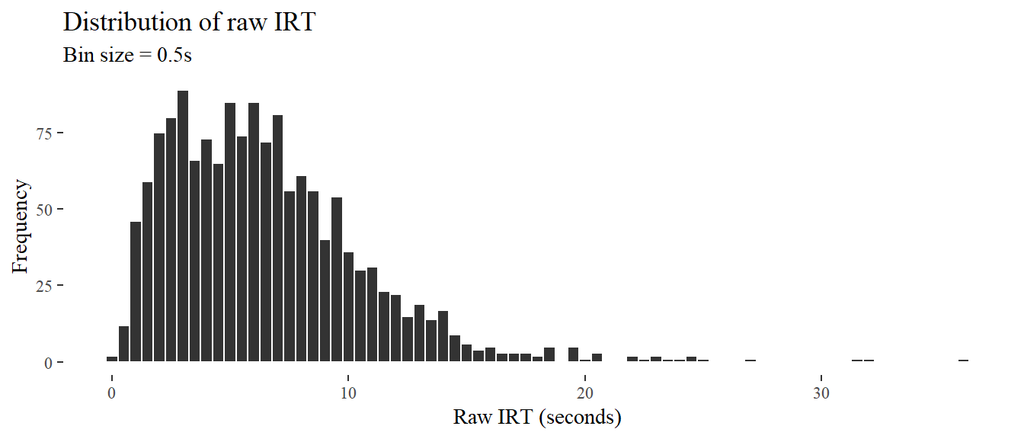

Distribution of raw IRT

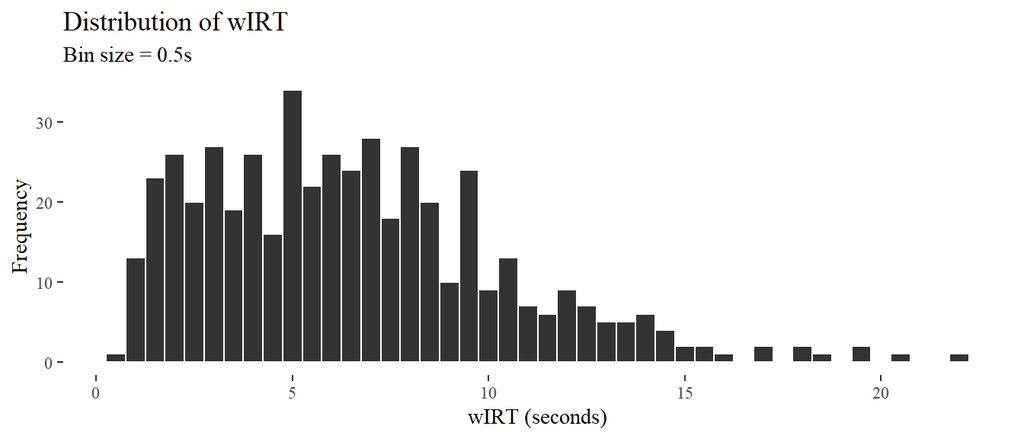

Distribution of wIRT

#### Means by condition

Means (s) by condition

| Condition | D | Q |
| --- | --- | --- |
| -GP | 6.20 | 6.47 |
| +GP | 6.61 | 6.85 |
| Increase | 0.41 | 0.37 |

The difference in the effect of ±GP across ±Q is 0.04s. That is, the mean amount that IRT increased for a garden path declarative compared to a non-garden path declarative is 0.04s more than the amount that IRT increased for a garden path interrogative compared to a non-garden path interrogative.

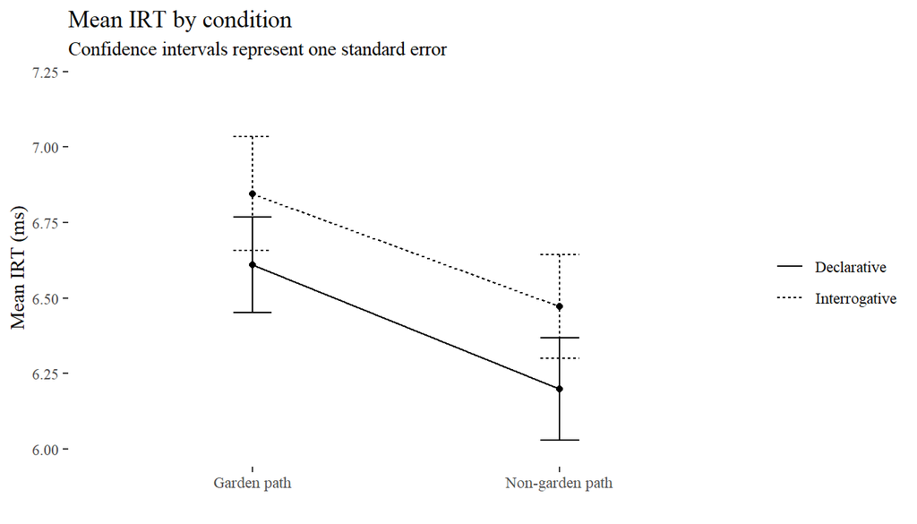

Mean IRT by condition

#### Regression models of IRT

The models with random slopes for participant and item did not converge, so the tables in this section show models with no random slopes.

For the first model, fixed effects of ±GP and ±Q as well is the interaction between them were included, along with random effects of participant and item. The second model removes the interaction, but keeps both main effects.

Models

|  | Full | No interaction | No random effects | No fixed effects |
| --- | --- | --- | --- | --- |
| +GP | 416.401 | 456.133 | 411.636 |  |
|  | (299.877) | (212.357) | (487.484) |  |
| Q | 288.168 | 327.554 | 272.462 |  |
|  | (298.528) | (212.313) | (485.506) |  |
| +GP Q | 79.786 |  | -36.931 |  |
|  | (425.161) |  | (690.156) |  |
| N | 489 | 489 | 489 | 489 |
| logLik | -4544.769 | -4544.787 | -4724.504 | -4548.229 |
| AIC | 9103.538 | 9101.573 | 9459.008 | 9104.458 |

Full model vs. no fixed effects

|  | Df | AIC | BIC | logLik | deviance | $\chi^2$ | Df($\chi$) | Pr(>$\chi^2$) |
| --- | --- | --- | --- | --- | --- | --- | --- | --- |
| No fixed effects | 4 | 9104.458 | 9121.228 | -4548.229 | 9096.458 | NA | NA | NA |
| Full | 7 | 9103.538 | 9132.885 | -4544.769 | 9089.538 | 6.920059 | 3 | 0.0744899 |

Full model vs. no interaction

|  | Df | AIC | BIC | logLik | deviance | $\chi^2$ | Df($\chi$) | Pr(>$\chi^2$) |
| --- | --- | --- | --- | --- | --- | --- | --- | --- |
| No interaction | 6 | 9101.573 | 9126.728 | -4544.787 | 9089.573 | NA | NA | NA |
| Full | 7 | 9103.538 | 9132.885 | -4544.769 | 9089.538 | 0.0352051 | 1 | 0.8511665 |

Full model vs. no random effects

|  | Df | AIC | BIC | logLik | deviance | $\chi^2$ | Df($\chi$) | Pr(>$\chi^2$) |
| --- | --- | --- | --- | --- | --- | --- | --- | --- |
| No random effects | 5 | 9459.008 | 9479.970 | -4724.504 | 9449.008 | NA | NA | NA |
| Full | 7 | 9103.538 | 9132.885 | -4544.769 | 9089.538 | 359.4701 | 2 | 0 |

#### Effect of verb on IRT

Mean (sd) wIRT by condition and verb in seconds

| Verb | D -GP | D +GP | Q -GP | Q +GP |
| --- | --- | --- | --- | --- |
| cram | 6.4 (3.9) | 6.9 (4) | 5.9 (3.1) | 6.5 (3.8) |
| put | 6.5 (3.8) | 6.8 (3.7) | 6 (3.3) | 7 (5.2) |
| set | 6.1 (3.2) | 6.3 (3.2) | 7.4 (4.5) | 6.6 (3.6) |
| stick | 5.8 (4.2) | 6.5 (3.2) | 6.7 (4.1) | 7.4 (4.2) |

Effect of GP on wIRT by verb

| Verb | Declarative GP effect | Interrogative GP effect | Difference in effect |
| --- | --- | --- | --- |
| cram | 0.5 | 0.6 | -0.1 |
| put | 0.3 | 1.0 | -0.8 |
| set | 0.2 | -0.9 | 1.0 |
| stick | 0.7 | 0.7 | 0.0 |

#### Individual variation in IRT

Mean wIRT (ms) by condition and participant

| Participant | D -GP | D +GP | Q -GP | Q +GP |
| --- | --- | --- | --- | --- |
| 10 | 9072.500 | 9416.155 | 8734.438 | 9630.157 |
| 5 | 13082.620 | 10694.565 | 9437.685 | 12188.125 |
| 1 | 2723.095 | 2764.875 | 3165.468 | 3061.438 |
| 2 | 6077.595 | 7088.435 | 4410.845 | 6398.435 |
| 3 | 5655.472 | 8400.845 | 6056.405 | 7267.347 |
| 4 | 7993.717 | 5457.905 | 10609.750 | 7010.720 |
| 6 | 12848.093 | 10828.407 | 13018.030 | 14695.872 |
| 7 | 5706.287 | 5864.283 | 6291.778 | 4918.595 |
| 9 | 6234.815 | 6632.685 | 6386.938 | 6484.312 |
| 11 | 8635.833 | 9030.440 | 5688.040 | 12075.837 |
| 12 | 5436.092 | 5236.717 | 6146.935 | 7347.062 |
| 13 | 10779.875 | 11638.595 | 9410.875 | 10931.093 |
| 14 | 7180.315 | 8851.722 | 8443.062 | 12052.435 |
| 15 | 9673.310 | 7771.158 | 9463.500 | 5764.438 |
| 16 | 12583.907 | 9725.440 | 9352.470 | 15201.440 |
| 17 | 3725.878 | 6283.250 | 5736.560 | 5128.127 |
| 19 | 10846.250 | 13891.583 | 14803.670 | NA |
| 20 | 9963.565 | 9211.125 | 12225.282 | 10081.030 |
| 21 | 5035.065 | 5748.627 | 6117.688 | 7204.748 |
| 22 | 5066.752 | 4134.533 | 5006.845 | 7975.283 |
| 201 | 1396.033 | 4249.562 | 2533.628 | 2206.812 |
| 203 | 1451.470 | 1501.438 | 1909.753 | 2472.343 |
| 204 | 3164.688 | 3173.847 | 2792.125 | 1676.000 |
| 205 | 6456.967 | 11925.468 | 7450.278 | 11345.407 |
| 206 | 3736.810 | 3707.875 | 3223.593 | 4985.440 |
| 207 | 5083.280 | 6428.315 | 6700.748 | 5199.312 |
| 208 | 2612.250 | 3449.810 | 2482.940 | 3263.970 |
| 209 | 2126.185 | 3625.500 | 2563.718 | 2967.907 |
| 210 | 5690.440 | 6105.592 | 6664.688 | 5098.160 |
| 212 | 4699.658 | 5192.250 | 4647.190 | 5065.035 |
| 214 | 3628.378 | 4118.707 | 5185.467 | 2026.030 |
| 215 | 4432.130 | 4132.312 | 5207.998 | 5075.938 |

### Interrogative processing cost is represented in IRT

Interrogatives appear to have a computational processing cost when compared to interrogatives [cf. @mehler1963some, @qp2]. The filler sentences in this study were designed so as to provide a diagnostic of the interrogative effect on IRT.

|  | Only Interogitivity | Full | No interaction |
| --- | --- | --- | --- |
| (Intercept) | 6236.06 | 6261.55 | 6226.62 |
|  | (554.38) | (573.11) | (565.57) |
| Q | 379.21 | 311.62 | 379.40 |
|  | (155.31) | (236.77) | (155.32) |
| +GP |  | -49.00 | 18.69 |
|  |  | (284.55) | (221.71) |
| Q * +GP |  | 135.53 |  |
|  |  | (357.36) |  |
| N | 998 | 998 | 998 |
| logLik | -9278.27 | -9278.20 | -9278.27 |
| AIC | 18566.54 | 18570.39 | 18568.54 |
| *** p < 0.001; ** p < 0.01; * p < 0.05. |  |  |  |

## Delay comparison for cold vs. previewed readings

A comparison of the delay for cold readings compared with that of previewed readings can lend insight into the extent to which subjects followed task instructions.

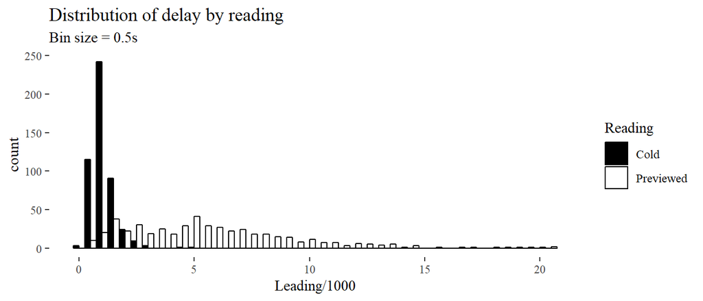

Delay comparison across reading

For each reading, n = 489 (total n = 978).

### Reading 1 delays by participant

[output not shown]

```
## Generalized linear mixed model fit by maximum likelihood (Laplace
##   Approximation) [glmerMod]
##  Family: binomial  ( logit )
## Formula: PP1 ~ Condition_Q * Condition_GP * r1DelCat + (1 | IID) + (1 |
##     SID)
##    Data: mmdata
##
##      AIC      BIC   logLik deviance df.resid
##    181.9    218.2    -80.9    161.9      269
##
## Scaled residuals:
##     Min      1Q  Median      3Q     Max
## -5.9490  0.0000  0.1236  0.3383  1.0373
##
## Random effects:
##  Groups Name        Variance Std.Dev.
##  SID    (Intercept) 0.5014   0.7081
##  IID    (Intercept) 0.9249   0.9617
## Number of obs: 279, groups:  SID, 18; IID, 16
##
## Fixed effects:
##                                                 Estimate Std. Error
## (Intercept)                                    1.020e+00  4.821e-01
## Condition_QTRUE                                1.191e+00  6.031e-01
## Condition_GPTRUE                               2.002e+01  4.944e+03
## r1DelCatSLOW                                   8.935e-01  7.440e-01
## Condition_QTRUE:Condition_GPTRUE              -1.788e+01  4.944e+03
## Condition_QTRUE:r1DelCatSLOW                  -2.224e+00  9.351e-01
## Condition_GPTRUE:r1DelCatSLOW                  3.858e-02  1.025e+04
## Condition_QTRUE:Condition_GPTRUE:r1DelCatSLOW  8.350e-01  1.025e+04
##                                               z value Pr(>|z|)
## (Intercept)                                     2.115   0.0344 *
## Condition_QTRUE                                 1.974   0.0484 *
## Condition_GPTRUE                                0.004   0.9968
## r1DelCatSLOW                                    1.201   0.2297
## Condition_QTRUE:Condition_GPTRUE               -0.004   0.9971
## Condition_QTRUE:r1DelCatSLOW                   -2.378   0.0174 *
## Condition_GPTRUE:r1DelCatSLOW                   0.000   1.0000
## Condition_QTRUE:Condition_GPTRUE:r1DelCatSLOW   0.000   0.9999
## ---
## Signif. codes:  0 '***' 0.001 '**' 0.01 '*' 0.05 '.' 0.1 ' ' 1
##
## Correlation of Fixed Effects:
##                   (Intr) Cn_QTRUE Cn_GPTRUE r1DCSL Cn_QTRUE:C_GPTRUE
## Cndtn_QTRUE       -0.444
## Cndt_GPTRUE        0.000  0.000
## r1DelCtSLOW       -0.483  0.297    0.000
## Cn_QTRUE:C_GPTRUE  0.000  0.000   -1.000     0.000
## C_QTRUE:1DC        0.297 -0.661    0.000    -0.639  0.000
## C_GPTRUE:1D        0.000  0.000   -0.482     0.000  0.482
## C_QTRUE:C_GPTRUE:  0.000  0.000    0.482     0.000 -0.482
##                   C_QTRUE:1 C_GPTRUE:
## Cndtn_QTRUE
## Cndt_GPTRUE
## r1DelCtSLOW
## Cn_QTRUE:C_GPTRUE
## C_QTRUE:1DC
## C_GPTRUE:1D        0.000
## C_QTRUE:C_GPTRUE:  0.000    -1.000
## convergence code: 0
## unable to evaluate scaled gradient
## Model failed to converge: degenerate  Hessian with 2 negative eigenvalues
```

```
## Generalized linear mixed model fit by maximum likelihood (Laplace
##   Approximation) [glmerMod]
##  Family: binomial  ( logit )
## Formula: OBJ ~ Condition_Q * Condition_GP * r1DelCat + (1 | IID) + (1 |
##     SID)
##    Data: mmdata
##
##      AIC      BIC   logLik deviance df.resid
##    297.3    333.6   -138.7    277.3      269
##
## Scaled residuals:
##     Min      1Q  Median      3Q     Max
## -6.0651  0.1412  0.3452  0.5077  1.5630
##
## Random effects:
##  Groups Name        Variance Std.Dev.
##  SID    (Intercept) 0.8317   0.9120
##  IID    (Intercept) 0.6235   0.7896
## Number of obs: 279, groups:  SID, 18; IID, 16
##
## Fixed effects:
##                                               Estimate Std. Error z value
## (Intercept)                                     1.5058     0.5301   2.840
## Condition_QTRUE                                -0.2619     0.5501  -0.476
## Condition_GPTRUE                               -0.6689     0.5410  -1.237
## r1DelCatSLOW                                    1.6698     0.9717   1.718
## Condition_QTRUE:Condition_GPTRUE                0.7653     0.7879   0.971
## Condition_QTRUE:r1DelCatSLOW                   -1.2731     1.0678  -1.192
## Condition_GPTRUE:r1DelCatSLOW                  -0.9909     1.0651  -0.930
## Condition_QTRUE:Condition_GPTRUE:r1DelCatSLOW   1.1607     1.4246   0.815
##                                               Pr(>|z|)
## (Intercept)                                     0.0045 **
## Condition_QTRUE                                 0.6341
## Condition_GPTRUE                                0.2163
## r1DelCatSLOW                                    0.0857 .
## Condition_QTRUE:Condition_GPTRUE                0.3314
## Condition_QTRUE:r1DelCatSLOW                    0.2332
## Condition_GPTRUE:r1DelCatSLOW                   0.3522
## Condition_QTRUE:Condition_GPTRUE:r1DelCatSLOW   0.4152
## ---
## Signif. codes:  0 '***' 0.001 '**' 0.01 '*' 0.05 '.' 0.1 ' ' 1
##
## Correlation of Fixed Effects:
##                   (Intr) Cn_QTRUE Cn_GPTRUE r1DCSL Cn_QTRUE:C_GPTRUE
## Cndtn_QTRUE       -0.546
## Cndt_GPTRUE       -0.559  0.544
## r1DelCtSLOW       -0.439  0.299    0.296
## Cn_QTRUE:C_GPTRUE  0.398 -0.712   -0.706    -0.210
## C_QTRUE:1DC        0.271 -0.522   -0.283    -0.716  0.373
## C_GPTRUE:1D        0.272 -0.285   -0.510    -0.719  0.364
## C_QTRUE:C_GPTRUE: -0.213  0.408    0.399     0.544 -0.568
##                   C_QTRUE:1 C_GPTRUE:
## Cndtn_QTRUE
## Cndt_GPTRUE
## r1DelCtSLOW
## Cn_QTRUE:C_GPTRUE
## C_QTRUE:1DC
## C_GPTRUE:1D        0.660
## C_QTRUE:C_GPTRUE: -0.764    -0.760
## convergence code: 0
## Model failed to converge with max|grad| = 0.00313291 (tol = 0.001, component 1)
```

### Difference in delay across paired readings

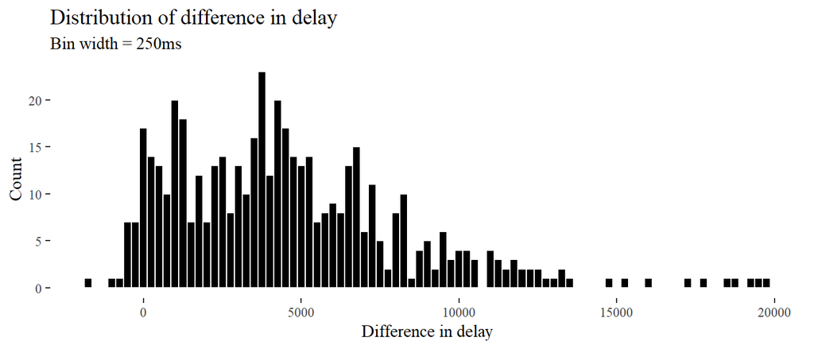

Distribution of DelDif

Delay differences by participant

| Participant | Mean difference in delay (ms) |
| --- | --- |
| 1 | 386 |
| 203 | 938 |
| 208 | 1183 |
| 209 | 1290 |
| 204 | 1502 |
| 201 | 1584 |
| 214 | 1604 |
| 206 | 2582 |
| 215 | 2814 |
| 21 | 2908 |
| 17 | 3139 |
| 212 | 3167 |
| 7 | 3752 |
| 9 | 3816 |
| 210 | 3908 |
| 22 | 3973 |
| 207 | 3988 |
| 12 | 4303 |
| 2 | 4369 |
| 3 | 4841 |
| 4 | 5676 |
| 11 | 6177 |
| 10 | 6358 |
| 14 | 7157 |
| 15 | 7286 |
| 205 | 7434 |
| 5 | 7838 |
| 13 | 8001 |
| 20 | 8685 |
| 16 | 10269 |
| 6 | 10624 |
| 19 | 10820 |

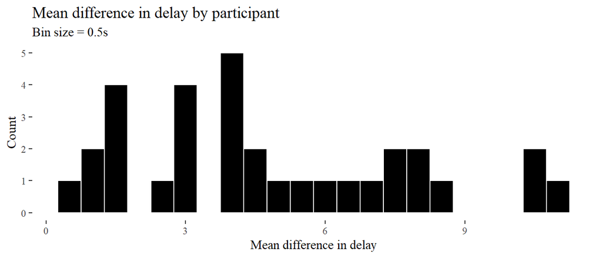

Mean difference in delay by participant

# Discussion

This section will go through the motivating questions behind this study and discuss the extent to which those questions are answered, or not. It will discuss the issues that may have lead to some results that were disatisfying and how to correc them for futuer work. It will then go on to present further questions and propose further studies to explore those new questions and the ones left unanswered here.

## Explaining the intuition

A possible explanation for the intuitive effect of interogativity on parsing garden paths is provided in the work by @Bader1998-ts. Bader demonstrates that it is easier to recover a parse that “behave[s] alike prosodically” to a given failed parse, because the reanalysis does not require prosodic reconstruction and only the syntax needs to be repaired. In the case of the intuition this study is concerned with, this would mean that should sentences be more similar across the garden path vs. non-garden path condition in the interrogative than in the declarative, the intuitive reduction in difficulty of reanalysis would naturally follow.

|  | Non-garden path D | Non-garden path Q | Garden path D | Garden path Q |
| --- | --- | --- | --- | --- |
| Both | 54.1 | 43.0 | 72.1 | 71.7 |
| OBJ | 31.1 | 31.4 | 0.8 | 2.5 |
| PP1 | 14.8 | 25.6 | 27.0 | 25.8 |

While there is a larger drop in the number of utterances with both breaks from +GP to -GP for questions than for decaratives, the opposite is true for the pattern with a PP1 break by itself. There is an argument to be made that the OBJ break, which does not correspond to a change in syntactic branching direction for any version of the sentences, is a hesitation rather than a break, due to a moment of confusion or perhaps simply a need to breathe. If the PP1 break is treated as the main indicator of the prosodic structure, then the larger difference across ±GP for declaratives (12.2%) than for interrogatives (0.2%) does indeed, however weakly, leave open the door for the Bader (1998) explanation of the intuition.

## Confounds

# Conclusion

Discussion of what is still unknown, and suggestions of future research.

## Issues with the reported study

Statistical significance for the behavioral correlate of the intuition: more participants

## Ways to improve for a similar future study

Follow-up task to check understanding and interpretation of the sentence

Improve IRT accuracy by anticipating the participant’s desire to study slide 1 and either forcing it to disappear or else assuming that to be their study time.

## Fruitful avenues for further study

ERP-based study: check for Closure Positive Shift (CPS) at PP attachment sites; check for P600/N400 at site of disambiguation. CPS should reveal the tree being parsed for each condition; higher frequency and larger amplitude of P600/N400 across the GP condition in declaratives vs. interrogatives would illustrate the intuitive observation.

Eye-tracking: more regressions and longer reading time across the GP condition in declaratives vs. interrogatives would illustrate the intuitive observation.

# Instructions to participants {instr}

The instructions are presented below.

> Thank you kindly for your participation. In this study, you are being asked to read complex sentences out loud, twice each. It is very important that you follow these guidelines for each of your readings.

> First reading: Begin reading immediately, without giving yourself a chance to look ahead. Imagine you are a television reporter reading an urgent update from a teleprompter. You must be as quick as possible, without taking any time to read ahead. You want to sound natural if you can, but it is more important to not delay. These sentences are complicated and potentially confusing. It’s very important that you read the sentence out loud as soon as it appears. It’s OK if you make mistakes or don’t understand, that is an important part of what I want to know. Do the best you can, and remember you have another chance to read it.

> Second reading: This time you have the luxury of pacing yourself as you please. Imagine you are providing a voice-over for a documentary. You want to sound conversational and clear, without being overly dramatic or formal. Study the sentence as long as you like, and be sure that you understand it before you begin reading. It is most important to sound natural, without worrying about how long it takes to prepare.

> The experiment will begin with brief instructions, recapping what you are reading now. There will then be a practice session to get you comfortable with the task and a chance for you to ask any questions you have. Finally, after your questions are answered, the study will begin in earnest.

> Each sentence will follow the same pattern. You will be presented with a screen which displays a series of plus signs. This indicates that the system is ready and that you should press the button labeled “START” when you are ready to read a sentence. As soon as you press the button, the sentence will appear and you should begin your first reading. After you have completed the reading, press the button labeled “NEXT.” You should allow a small amount of time after you finish and before you hit “NEXT,” to ensure that the recording is not cut off too early.

> Once you have pressed “NEXT,” you will see a brief instructions slide to help you keep track of where you are. You should then press “START” and begin preparing to read the second time. The background color will change to confirm that the computer has registered your key press. Once you’re ready, read the sentence aloud for the second time and then press “DONE.” Once again, be sure not to cut yourself off. Wait a moment after you finish reading before pressing “DONE.”

> You are not being judged or measured in any way. Rather, we are interested in how these sentences are pronounced by native speakers of English. Any confusion you have or mistakes you make are interesting properties of the sentences, not failings of you, the speaker.

> The keys used during the experiment are clearly labeled, but the function of each key is listed below for your reference. There is no hurry for pressing the keys. The only timing of importance is that you begin reading as quickly as possible after pressing “START.” The task should take no longer than one hour

# Instructions to RA

Before you begin describing the recordings for a given speaker, please familiarize yourself with that speaker. To do so, please listen to recordings numbered 46-48 and 24-27.

Next, move on to describings the recordings numbered 1-16. Please listen to them in the following pattern: begin with either 1Y or 1X, and listen to the recordings sequentially (or reverse sequentially), and alternate between X and Y versions. Then, repeat the process for the inverse versions (X vs. Y). Please then listen to the next speaker, beginning with 16X or Y, and then listen in reverse sequence, alternating X vs. Y, and then again repeat for the other half. In this way, please alternate across speakers between listening to X or Y first as well as 1 or 16 first.

For each recording, please respond in the spreadsheet using the following guidelines for the columns. Each recording should get its own row.

- Speaker ID: This should be the name of the directory in which the recording exists.
- Recording ID: This should be the filename of the recording being described
- X or Y: This should be the last character of the filename, either X or Y.
- First recording for speaker: This should indicate which recording you started with first, which will allow me to deduce the pattern you used to listened to the recordings, per above, e.g. 1X, 1Y, 16X or 16Y.

For columns E-K, Consider a given sentence to be divided into regions, as in the following example:

```r
Sentence = c("He", "had", "meant", "to stick ||$_V$", "the pencil case ||$_{OBJ}$", "in the cabinet ||$_{PP1}$", "into his book bag.")
Syntax = c("NP$_{SUBJ}$", "AUX", "V$_1$", "V$_2$", "NP$_{OBJ}$", "PP$_1$", "PP$_2$")
region = c("SUBJ", " ", "V", " ", "OBJ", "PP1", "PP2")
tab = rbind(Sentence,Syntax)
colnames(tab) <- region
kable(tab, booktab=T, caption="Sentence region labels", escape=F,row.names = F) %>%
  kable_styling(latex_options = c("scale_down","hold_position"))
```

[output not shown]

Please work with the assumption that “prosodic boundary” in what follows is any subset of the following features, clustered in such a way as to trigger your intuition that a new prosodic element (of any size) is beginning: pitch change, volume change, segmental lengthening, or pause.

- Break after V?: Please indicate whether or not you think there is a prosodic boundary after the verb cluster(at the right edge of the last/main verb).
- Break after OBJ?: Please indicate whether or not you think there is a prosodic boundary after the first NP in the object region (at the right edge of the first NP in the object region).
- Break after PP1?: Please indicate whether or not you think there is a prosodic boundary after the first NP in the PP1 region (at the right edge of the first NP in the PP region).
- Strongest break? Please indicate which of the breaks (columns E-G where you indicated YES) you think is strongest. If two breaks are of equal strength and are stronger than a third, indicate NONE as strongest. If two breaks are of equal strength and are weaker than a third, indicate that third break as strongest. If all breaks are the same strength, indicate NONE as strongest.
- Weakest break? Please indicate which of the breaks (columns E-G where you indicated YES) you think is weakest. If two breaks are of equal strength and are weaker than a third, indicate NONE as weakest. If two breaks are of equal strength and are stronger than a third, indicate that third break as weakest. If all breaks are the same strength, indicate NONE as weakest
- Struggle?: Indicate whether or not the speaker appears to have had difficulty reading the sentence. This should be relative to their baseline reading fluency, so if a person is hesitant every time, hesitance should not be enough to indicate a struggle.
- Start of struggle: indicate the region in which you first notice the speaker struggling. *Question?: indicate simply whether or not the recording sounds like a question, prosodically (e.g. final rise is present).

# Experimental instructions

Thank you kindly for your participation. In this study, you are being asked to read complex sentences out loud, twice each. It is very important that you follow these guidelines for each of your readings.

First reading: Begin reading immediately, without giving yourself a chance to look ahead. Imagine you are a television reporter reading an urgent update from a teleprompter. You must be as quick as possible, without taking any time to read ahead. You want to sound natural if you can, but it is more important to not delay. These sentences are complicated and potentially confusing. It’s very important that you read the sentence out loud as soon as it appears. It’s OK if you make mistakes or don’t understand, that is an important part of what I want to know. Do the best you can, and remember you have another chance to read it.

Second reading: This time you have the luxury of pacing yourself as you please. Imagine you are providing a voice-over for a documentary. You want to sound conversational and clear, without being overly dramatic or formal. Study the sentence as long as you like, and be sure that you understand it before you begin reading. It is most important to sound natural, without worrying about how long it takes to prepare.

The experiment will begin with brief instructions, recapping what you are reading now. There will then be a practice session to get you comfortable with the task and a chance for you to ask any questions you have. Finally, after your questions are answered, the study will begin in earnest.

Each sentence will follow the same pattern. You will be presented with a screen which displays a series of plus signs. This indicates that the system is ready and that you should press the button labeled “START” when you are ready to read a sentence. As soon as you press the button, the sentence will appear and you should begin your first reading. After you have completed the reading, press the button labeled “NEXT.” You should allow a small amount of time after you finish and before you hit “NEXT,” to ensure that the recording is not cut off too early.

Once you have pressed “NEXT,” you will see a brief instructions slide to help you keep track of where you are. You should then press “START” and begin preparing to read the second time. The background color will change to confirm that the computer has registered your key press. Once you’re ready, read the sentence aloud for the second time and then press “DONE.” Once again, be sure not to cut yourself off. Wait a moment after you finish reading before pressing “DONE.”

You are not being judged or measured in any way. Rather, we are interested in how these sentences are pronounced by native speakers of English. Any confusion you have or mistakes you make are interesting properties of the sentences, not failings of you, the speaker.

The keys used during the experiment are clearly labeled, but the function of each key is listed below for your reference. There is no hurry for pressing the keys. The only timing of importance is that you begin reading as quickly as possible after pressing “START.” The task should take no longer than one hour

[^1]: @Hedberg2017-er use ↑ to indicate an upstep, which is not standardly transcribed with ToBI.
[^2]: Instructions were also provided verbally and via printout. Details on the instructions are available in the appendices @ref(sec:instr).
[^3]: Thank you to Dianne Bradley for making this observation, and for the very clever “prosecutorial” descriptor.
[^4]: Google’s VAD API only accepts WAV files with sample rates that are a multiple of 8kHz. It ultimately downsamples all files to 8kHz, regardless of the input rate.
[^5]: The exact algorithm is available on [github](https://gist.github.com/moui72/4ebc4eb8f69eb9fdb1cab160ce299675) (URL: bit.ly/2uMrcrG)
[^6]: There are 32 participants, 16 items, and 2 readings, divided across 4 bins.